# Importing and Processing CSV Files

Marc Los Huertos

12/6/2016

## Importing CSV Files

First, we will import the CSV file. In most cases, we don’t need to preprocess the csv files.

```r
# Importing Scripts

file = "/home/CAMPUS/mawd2015/github/Climate_Change_Narratives/Data/87804MAW3.csv"

import = read.csv(file)
```

## Checking the Data

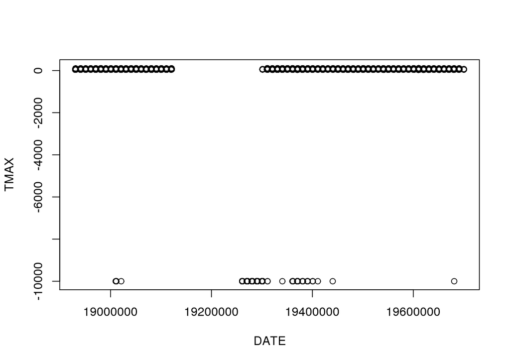

```r
plot(TMAX~DATE, import)
```

What’s going on? What is the deal with the -9999? These are used for missing data. We need to remove them!

```r
import$TMAX[import$TMAX==-9999] = NA
import$TMIN[import$TMIN==-9999] = NA
```

Okay, now we’ll check again, for dates less then Dec. 31, 1913:

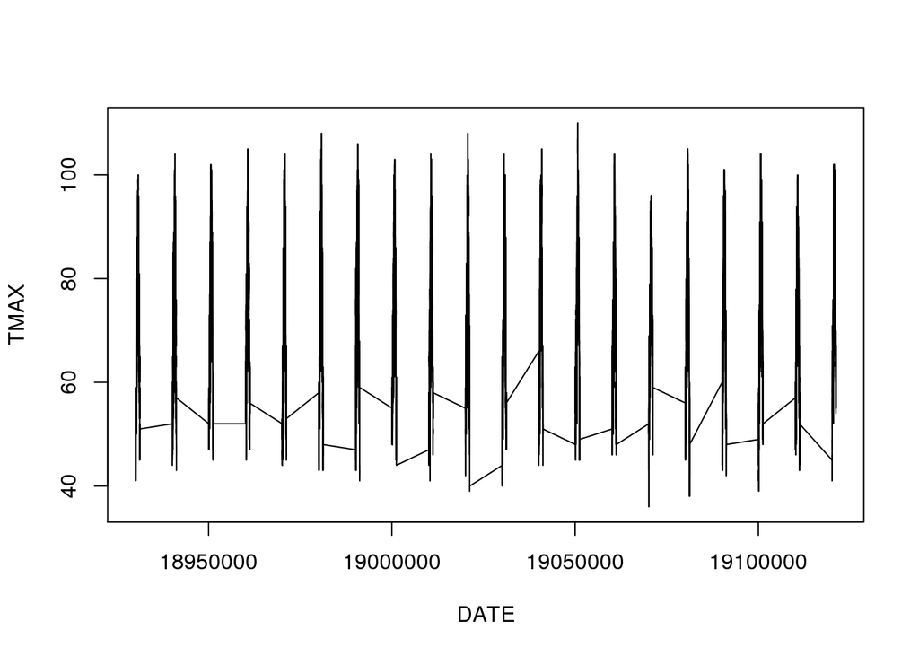

```r
plot(TMAX~DATE, import[import$DATE<19131231,], ty='l')
```

Yikes! What’s wrong? As it turns it the problem is that with how the dates are specified. In particular, the Dec 31 to Jan 1 transition:

19131231 -> 19140101, if you use these as numbers it should be 19131232, 19131232, etc. You see we are missing lots numbers!

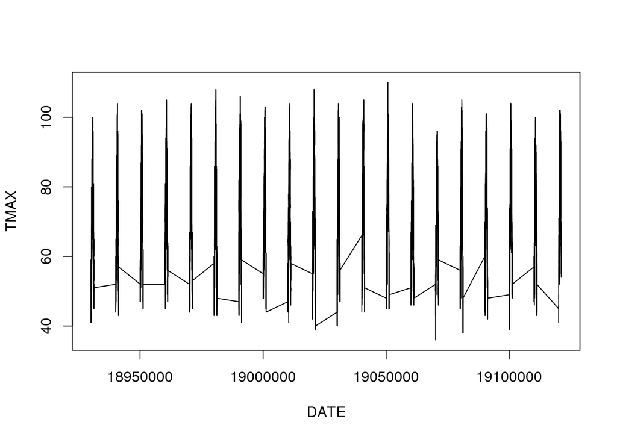

```r
plot(TMAX~DATE, import[import$DATE<19130102,], ty='l')
```

## Fixing the Dates

First, we convert the date a string or character values. Next, we’ll convert the strings to a data format.

```r
strDates <- as.character(import$DATE)
head(strDates)
```

```
## [1] "18930101" "18930102" "18930103" "18930104" "18930105" "18930106"
```

```r
import$NewDate <- as.Date(strDates, "%Y%m%d")
```

## Checking the New Dates

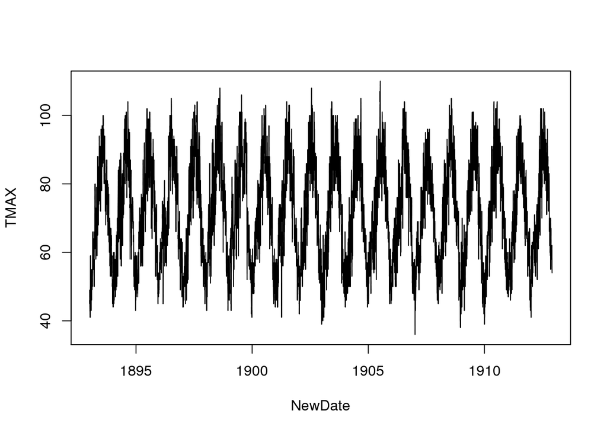

```r
plot(TMAX~NewDate, import[import$DATE<19130102,], ty='l')
```

## Subset Sites

```r
unique(import$STATION_NAME)
```

```
## [1] LODI CA US
## Levels: LODI CA US
```

```r
LosAngeles <- subset(import, STATION_NAME=="LODI CA US", select=c(STATION, STATION_NAME, DATE, NewDate, TMIN, TMAX, PRCP))
```

## A new plot

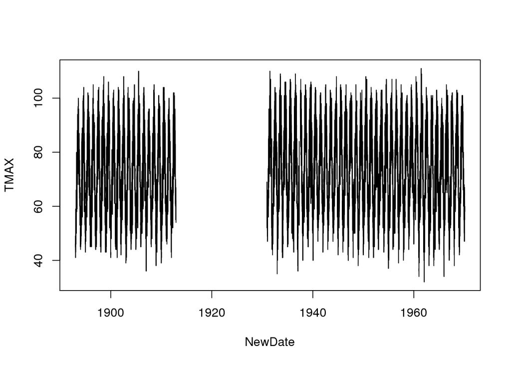

```r
plot(TMAX~NewDate, LosAngeles, ty='l')
```

## Evaluating the trend

Creating a linear model and then evaluate the rate (slope).

```r
# Linear Model
LosAngeles.lm <- lm(TMAX~NewDate, data=LosAngeles)
summary(LosAngeles.lm)
```

```
##
## Call:
## lm(formula = TMAX ~ NewDate, data = LosAngeles)
##
## Residuals:
##     Min      1Q  Median      3Q     Max
## -41.870 -12.432   0.048  12.300  37.881
##
## Coefficients:
##              Estimate Std. Error t value Pr(>|t|)
## (Intercept) 7.412e+01  1.805e-01 410.522  < 2e-16 ***
## NewDate     8.480e-05  1.144e-05   7.415 1.27e-13 ***
## ---
## Signif. codes:  0 '***' 0.001 '**' 0.01 '*' 0.05 '.' 0.1 ' ' 1
##
## Residual standard error: 15.03 on 21403 degrees of freedom
##   (1681 observations deleted due to missingness)
## Multiple R-squared:  0.002562,   Adjusted R-squared:  0.002515
## F-statistic: 54.98 on 1 and 21403 DF,  p-value: 1.266e-13
```

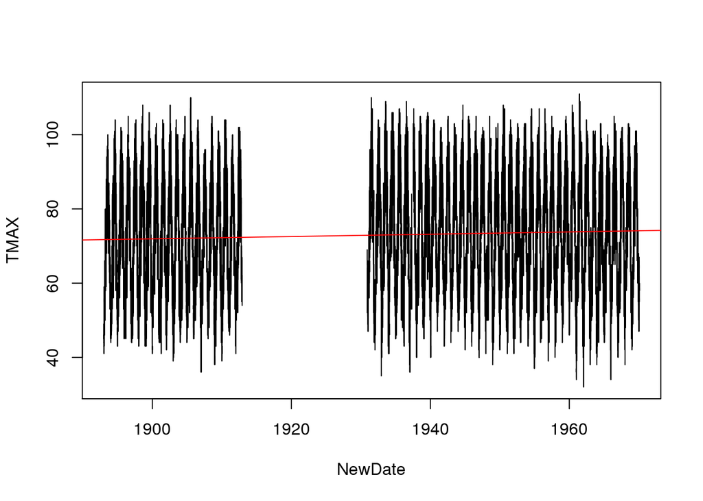

```r
plot(TMAX~NewDate, LosAngeles, ty='l')
abline(coef(LosAngeles.lm), col='red')
```

## Creating Month and Year Variables

So, let’s figure out how to see how changes happen for individual months.

```r
# Get months
LosAngeles$Month = months(LosAngeles$NewDate) # Creates problems.
LosAngeles$Month = format(as.Date(LosAngeles$NewDate), format = "%m")
LosAngeles$Year = format(LosAngeles$NewDate, format="%Y")
```

### Creating Monthly Means

```r
MonthlyMean = aggregate(TMAX ~ Month + Year, LosAngeles, mean)

MonthlyMean$YEAR = as.numeric(MonthlyMean$Year)
MonthlyMean$MONTH = as.numeric(MonthlyMean$Month)


# Frank -- change mean to sd and you'll get standard deviation for each month/year.

MonthlySD = aggregate(TMAX ~ Month + Year, LosAngeles, sd)

MonthlySD$YEAR = as.numeric(MonthlySD$Year)
MonthlySD$MONTH = as.numeric(MonthlySD$Month)
MonthlySD$NewDate = MonthlySD$YEAR + (MonthlySD$MONTH - 1)/12

head(MonthlySD)
```

```
##   Month Year     TMAX YEAR MONTH  NewDate
## 1    01 1893 5.284386 1893     1 1893.000
## 2    02 1893 5.223446 1893     2 1893.083
## 3    03 1893 6.697937 1893     3 1893.167
## 4    04 1893 5.427580 1893     4 1893.250
## 5    05 1893 6.759780 1893     5 1893.333
## 6    06 1893 6.151722 1893     6 1893.417
```

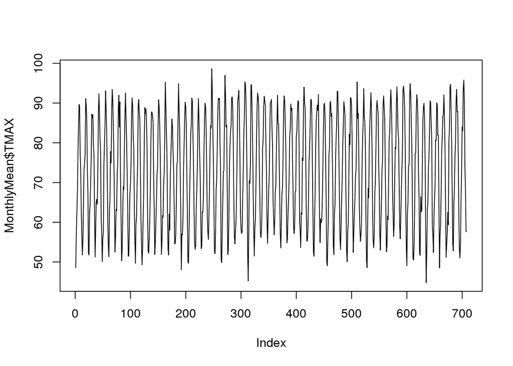

```r
plot(MonthlyMean$TMAX, ty='l')
```

below is sd

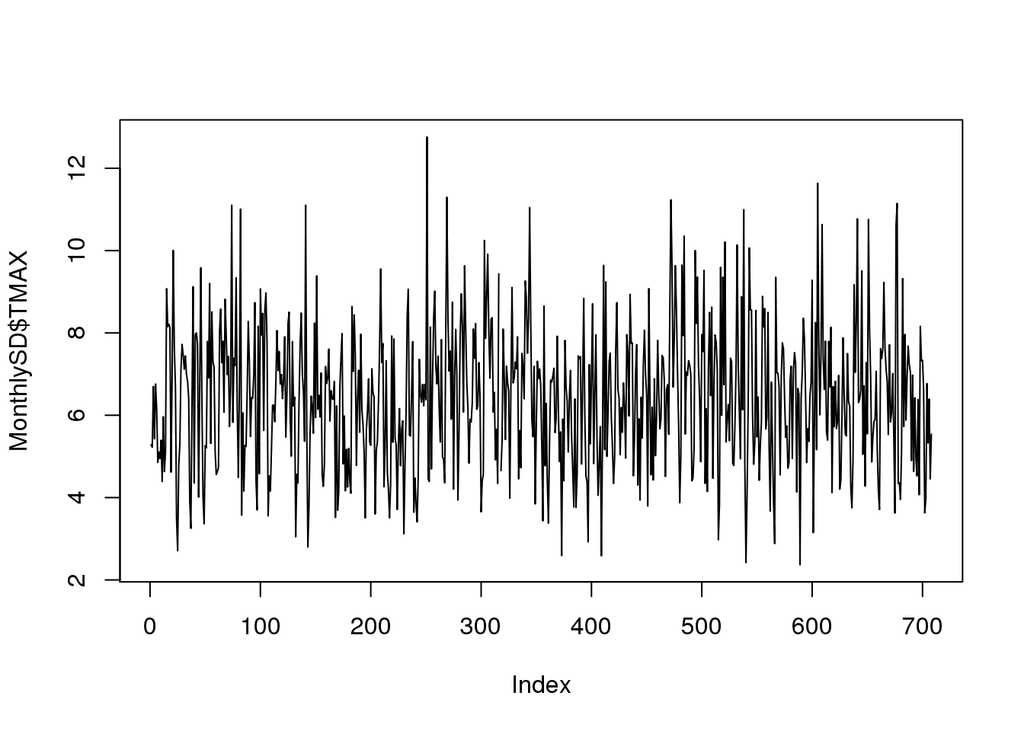

```r
plot(MonthlySD$TMAX, ty='l')
```

```r
plot(TMAX~ NewDate, data=MonthlySD, ty='l')
SD.lm <- lm(TMAX~NewDate, data=MonthlySD)
summary(SD.lm)
```

```
##
## Call:
## lm(formula = TMAX ~ NewDate, data = MonthlySD)
##
## Residuals:
##     Min      1Q  Median      3Q     Max
## -4.1372 -1.2022  0.0068  1.0618  6.3378
##
## Coefficients:
##             Estimate Std. Error t value Pr(>|t|)
## (Intercept) 0.708050   5.082397   0.139    0.889
## NewDate     0.002958   0.002627   1.126    0.261
##
## Residual standard error: 1.715 on 705 degrees of freedom
##   (1 observation deleted due to missingness)
## Multiple R-squared:  0.001795,   Adjusted R-squared:  0.0003788
## F-statistic: 1.268 on 1 and 705 DF,  p-value: 0.2606
```

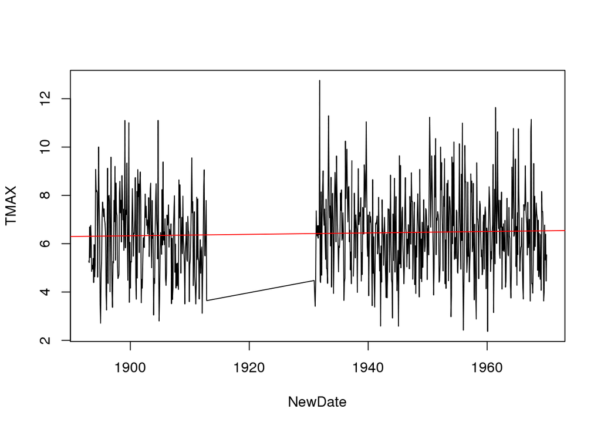

```r
abline(coef(SD.lm), col="red")
```

### Selecting for 1 Month – July

Perhaps, we can get a better handle on this stuff if we analyze for just one month at a time – certainly easier to visualize!

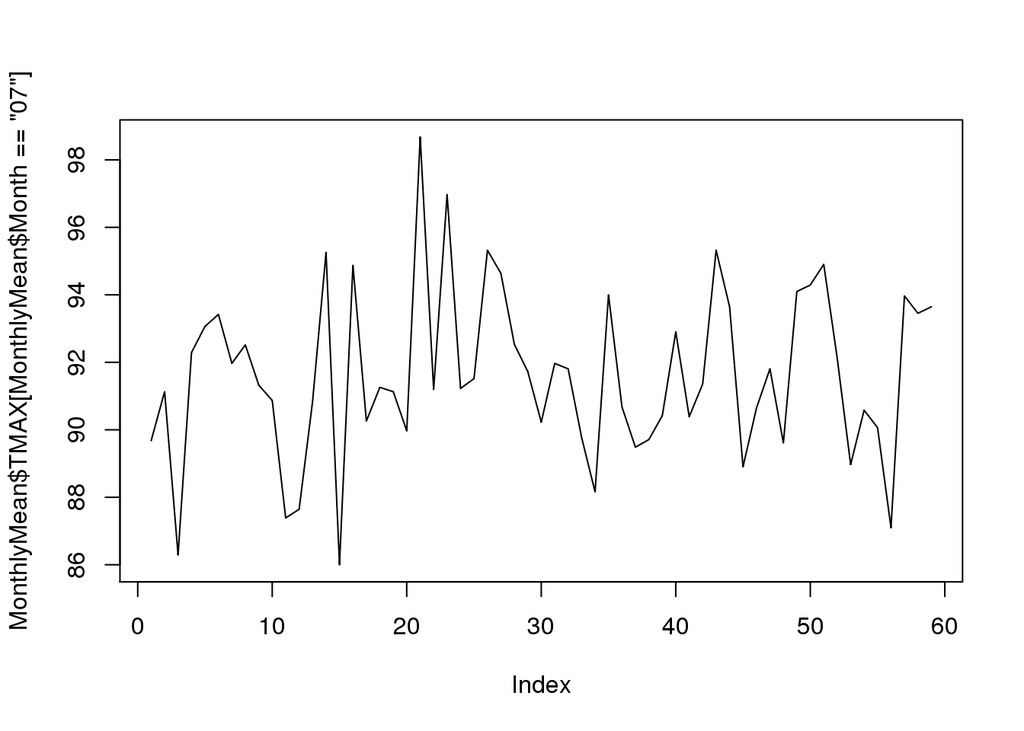

```r
plot(MonthlyMean$TMAX[MonthlyMean$Month=="07"], ty='l')
```

```r
plot(TMAX~YEAR, data=MonthlyMean[MonthlyMean$Month=="07",], ty='l')
July.lm <- lm(TMAX~YEAR, data=MonthlyMean[MonthlyMean$Month=="07",])
summary(July.lm)
```

```
##
## Call:
## lm(formula = TMAX ~ YEAR, data = MonthlyMean[MonthlyMean$Month ==
##     "07", ])
##
## Residuals:
##     Min      1Q  Median      3Q     Max
## -5.2359 -1.4533 -0.1086  1.6524  7.1082
##
## Coefficients:
##             Estimate Std. Error t value Pr(>|t|)
## (Intercept) 64.75567   26.01375   2.489   0.0157 *
## YEAR         0.01389    0.01345   1.032   0.3063
## ---
## Signif. codes:  0 '***' 0.001 '**' 0.01 '*' 0.05 '.' 0.1 ' ' 1
##
## Residual standard error: 2.532 on 57 degrees of freedom
## Multiple R-squared:  0.01835,    Adjusted R-squared:  0.001133
## F-statistic: 1.066 on 1 and 57 DF,  p-value: 0.3063
```

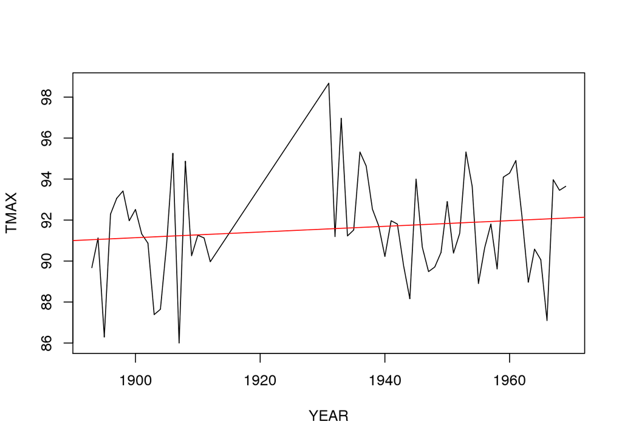

```r
abline(coef(July.lm), col="red")
```

Now, the change is 0.0138858 degress/year or 1.389 degress/100 years (YIKES!) with a probability of 0.3063. Although we can’t reject the null hypothesis, it is worrying!

## Next Steps

I think you should evaluate every month and see what happens. You might also consider looking at the TMIN as well. Could be important!

## Lets try June

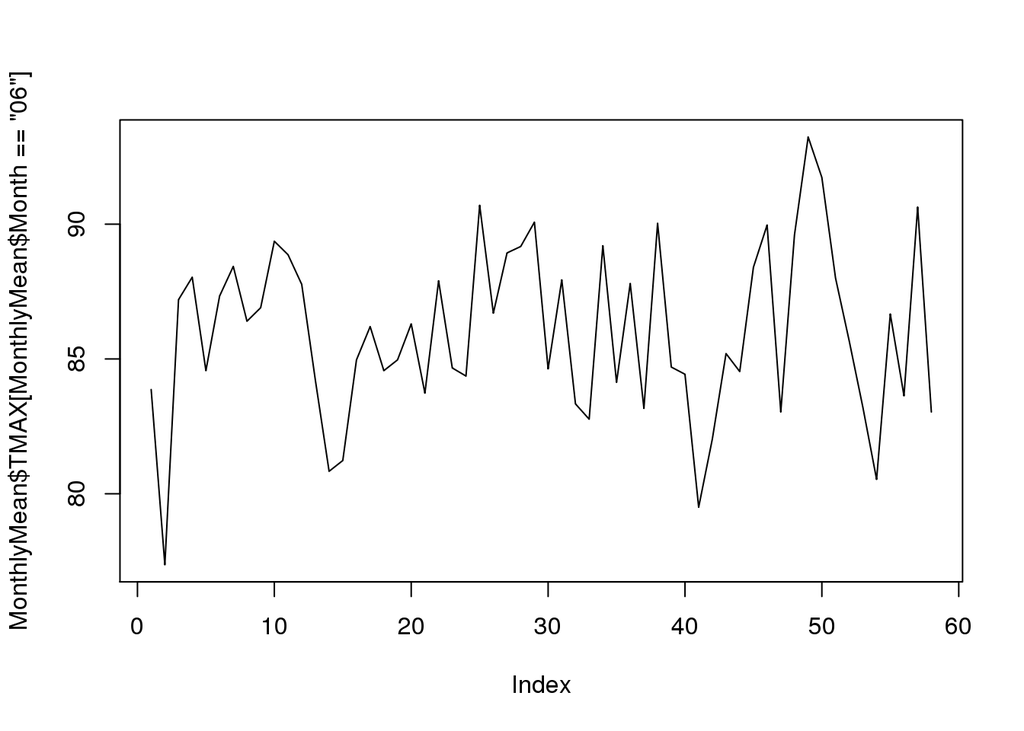

```r
plot(MonthlyMean$TMAX[MonthlyMean$Month=="06"], ty='l')
```

```r
plot(TMAX~YEAR, data=MonthlyMean[MonthlyMean$Month=="06",], ty='l')
June.lm <- lm(TMAX~YEAR, data=MonthlyMean[MonthlyMean$Month=="06",])
summary(June.lm)
```

```
##
## Call:
## lm(formula = TMAX ~ YEAR, data = MonthlyMean[MonthlyMean$Month ==
##     "06", ])
##
## Residuals:
##     Min      1Q  Median      3Q     Max
## -8.1409 -1.9192 -0.1617  2.4195  6.9573
##
## Coefficients:
##             Estimate Std. Error t value Pr(>|t|)
## (Intercept) 63.45685   32.98903   1.924   0.0595 .
## YEAR         0.01164    0.01706   0.683   0.4977
## ---
## Signif. codes:  0 '***' 0.001 '**' 0.01 '*' 0.05 '.' 0.1 ' ' 1
##
## Residual standard error: 3.21 on 56 degrees of freedom
## Multiple R-squared:  0.00825,    Adjusted R-squared:  -0.009459
## F-statistic: 0.4659 on 1 and 56 DF,  p-value: 0.4977
```

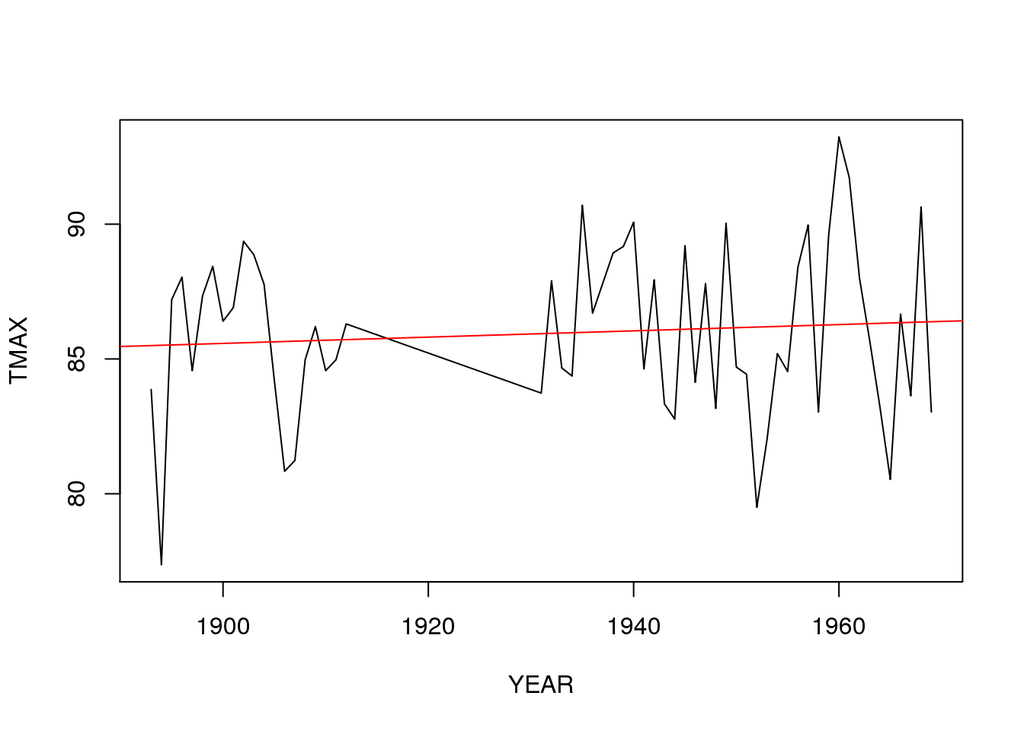

```r
abline(coef(June.lm), col="red")
```

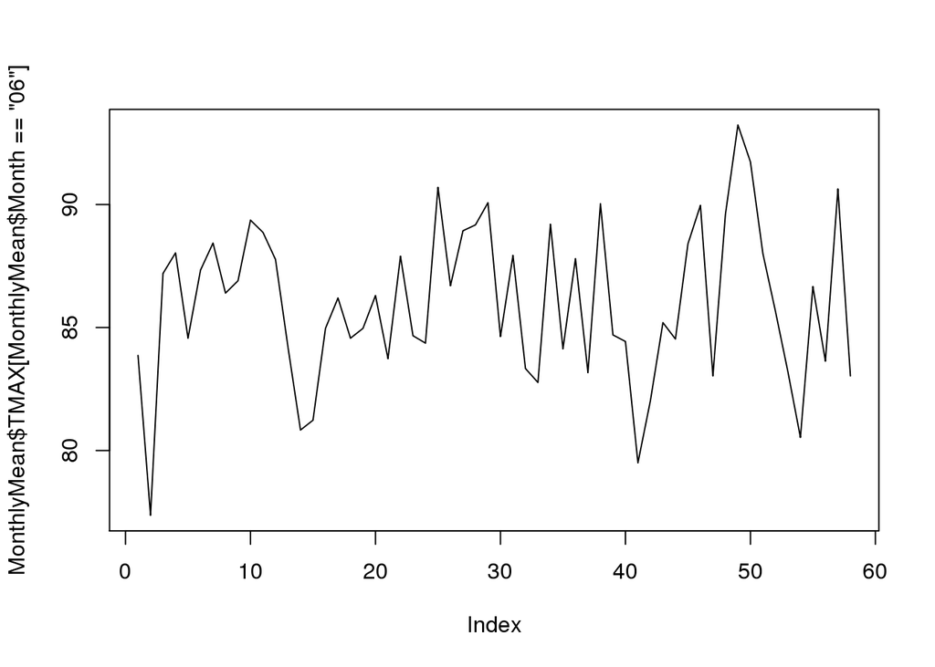

```r
plot(MonthlyMean$TMAX[MonthlyMean$Month=="06"], ty='l')
```

```r
plot(TMAX~YEAR, data=MonthlyMean[MonthlyMean$Month=="06",], ty='l')
June.lm <- lm(TMAX~YEAR, data=MonthlyMean[MonthlyMean$Month=="06",])
summary(June.lm)
```

```
##
## Call:
## lm(formula = TMAX ~ YEAR, data = MonthlyMean[MonthlyMean$Month ==
##     "06", ])
##
## Residuals:
##     Min      1Q  Median      3Q     Max
## -8.1409 -1.9192 -0.1617  2.4195  6.9573
##
## Coefficients:
##             Estimate Std. Error t value Pr(>|t|)
## (Intercept) 63.45685   32.98903   1.924   0.0595 .
## YEAR         0.01164    0.01706   0.683   0.4977
## ---
## Signif. codes:  0 '***' 0.001 '**' 0.01 '*' 0.05 '.' 0.1 ' ' 1
##
## Residual standard error: 3.21 on 56 degrees of freedom
## Multiple R-squared:  0.00825,    Adjusted R-squared:  -0.009459
## F-statistic: 0.4659 on 1 and 56 DF,  p-value: 0.4977
```

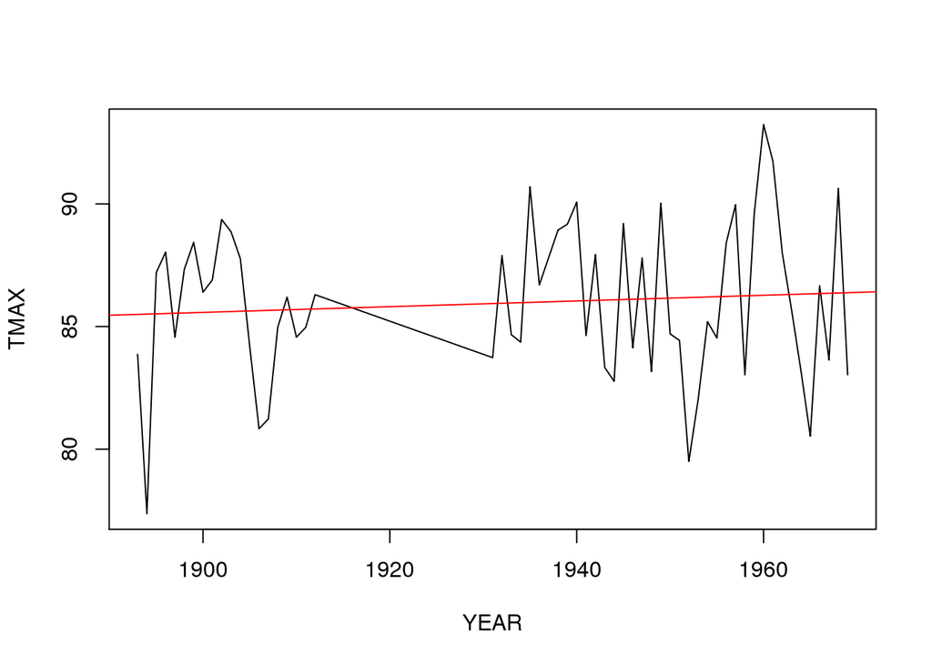

```r
abline(coef(June.lm), col="red")
```

Now, the change is 0.0116424 degress/year or 1.164 degress/100 years (YIKES!) with a probability of 0.4977. Although we can’t reject the null hypothesis, it is worrying!

## TMIN

1. We create a monthly mean for each month.

```r
MonthlyMeanTMIN = aggregate(TMIN ~ Month + Year, LosAngeles, mean)

MonthlyMeanTMIN$YEAR = as.numeric(MonthlyMeanTMIN$Year)
head(MonthlyMeanTMIN)
```

```
##   Month Year     TMIN YEAR
## 1    01 1893 39.83871 1893
## 2    02 1893 39.17857 1893
## 3    03 1893 44.00000 1893
## 4    04 1893 44.40000 1893
## 5    05 1893 49.67742 1893
## 6    06 1893 52.30000 1893
```

```r
MonthlyMeanTMIN = aggregate(TMIN ~ Month + Year, LosAngeles, mean)

MonthlyMeanTMIN$YEAR = as.numeric(MonthlyMeanTMIN$Year)
head(MonthlyMeanTMIN)
```

```
##   Month Year     TMIN YEAR
## 1    01 1893 39.83871 1893
## 2    02 1893 39.17857 1893
## 3    03 1893 44.00000 1893
## 4    04 1893 44.40000 1893
## 5    05 1893 49.67742 1893
## 6    06 1893 52.30000 1893
```

2. Now we plot the mins, and again, find tons of scatter.

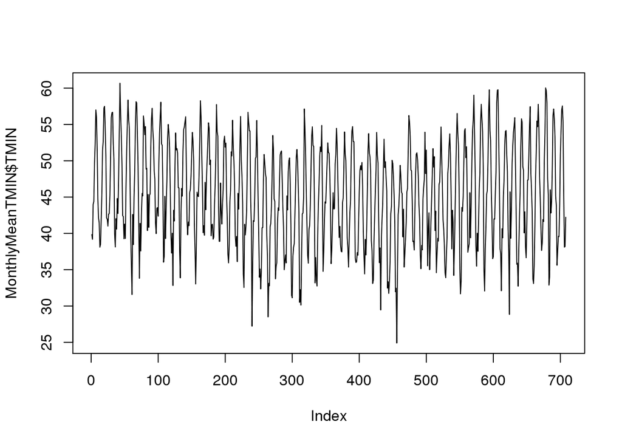

```r
plot(MonthlyMeanTMIN$TMIN, ty='l')
```

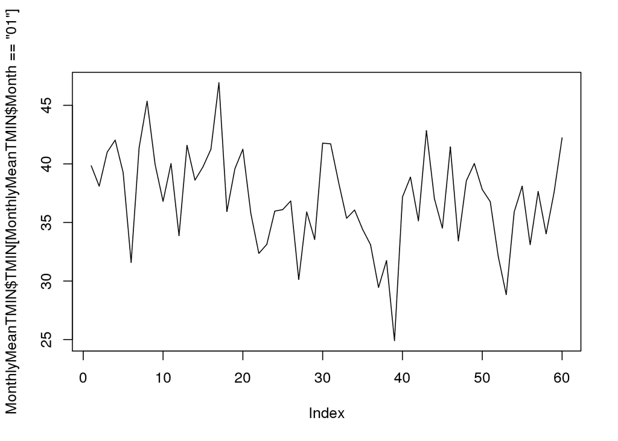

```r
plot(MonthlyMeanTMIN$TMIN[MonthlyMeanTMIN$Month=="01"], ty='l')
```

```r
plot(TMIN~YEAR, data=MonthlyMeanTMIN[MonthlyMeanTMIN$Month=="01",], ty='l')
Jan.lm <- lm(TMIN~YEAR, data=MonthlyMeanTMIN[MonthlyMeanTMIN$Month=="01",])
summary(Jan.lm)
```

```
##
## Call:
## lm(formula = TMIN ~ YEAR, data = MonthlyMeanTMIN[MonthlyMeanTMIN$Month ==
##     "01", ])
##
## Residuals:
##      Min       1Q   Median       3Q      Max
## -11.2783  -2.0964   0.0761   2.5879   8.3163
##
## Coefficients:
##              Estimate Std. Error t value Pr(>|t|)
## (Intercept) 154.95337   39.33545   3.939 0.000222 ***
## YEAR         -0.06094    0.02033  -2.997 0.004005 **
## ---
## Signif. codes:  0 '***' 0.001 '**' 0.01 '*' 0.05 '.' 0.1 ' ' 1
##
## Residual standard error: 3.896 on 58 degrees of freedom
## Multiple R-squared:  0.1341, Adjusted R-squared:  0.1192
## F-statistic: 8.983 on 1 and 58 DF,  p-value: 0.004005
```

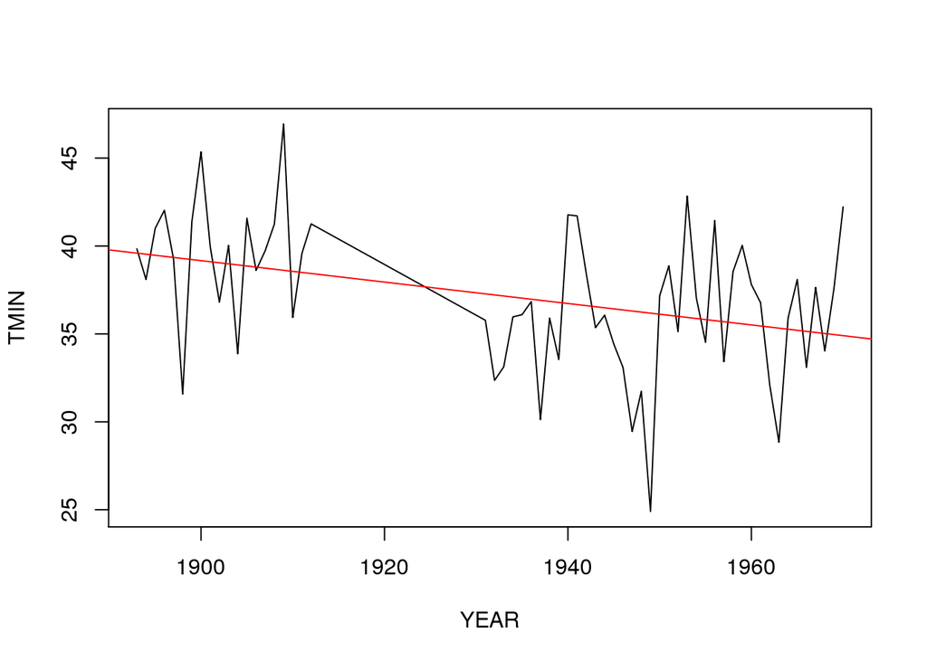

```r
abline(coef(Jan.lm), col="red")
```

# Departure from Mean

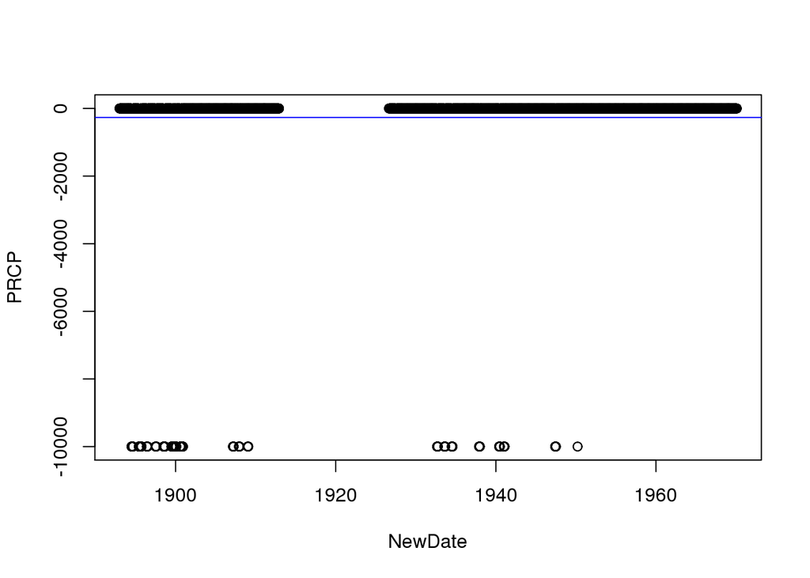

```r
PRCP_mean = mean(LosAngeles$PRCP, na.rm=T)

plot(PRCP~NewDate, data=LosAngeles)
abline(h=PRCP_mean, col="blue")
```

## Experimental Portion — Precipitation

Precipiation might depend more on the departure from the mean (often referred as as normal, whatever that means!). I think it’s worth pursuing, but haven’t finished the analysis yet.

First, we need a “mean” – The IPCC uses 1961-1990 as a norm, I don’t know what is the standard for California, so we should look that up.

Second, we need to remove the missing values and evalaute which years have complete years. If you are missing rainy months, then the whole year should be thrown out – but what about partial years in the drought season?

Third, we will need to decide what level of aggredation – monthly, yearly, etc.

Fourth, in CA the water year starts in Oct 1. Should we follow the same convention?

```r
LosAngeles$PRCP[LosAngeles$PRCP==-9999] <- NA
YearlySum = aggregate(PRCP ~ Year, LosAngeles, sum)
YearlySum$YEAR = as.numeric(YearlySum$Year)
YearlyMean = mean(YearlySum$PRCP)
```

A yearly mean, based on the annual sum for the entire records. Not sure this is appropriate.

Figure has points of the yearly sum of rainfall and the blue line mean. The greenline is the trend and red line is a five year running average, I think! I am still trying to understand what the code is doing.

```r
plot(PRCP~YEAR, data=YearlySum, las=1, ty="p")
abline(h=YearlyMean, col="blue")
YearlySum.lm = lm(PRCP~YEAR, data=YearlySum)
abline(coef(YearlySum.lm), col="green")

n <- 5
k <- rep(1/n, n)
k
```

```
## [1] 0.2 0.2 0.2 0.2 0.2
```

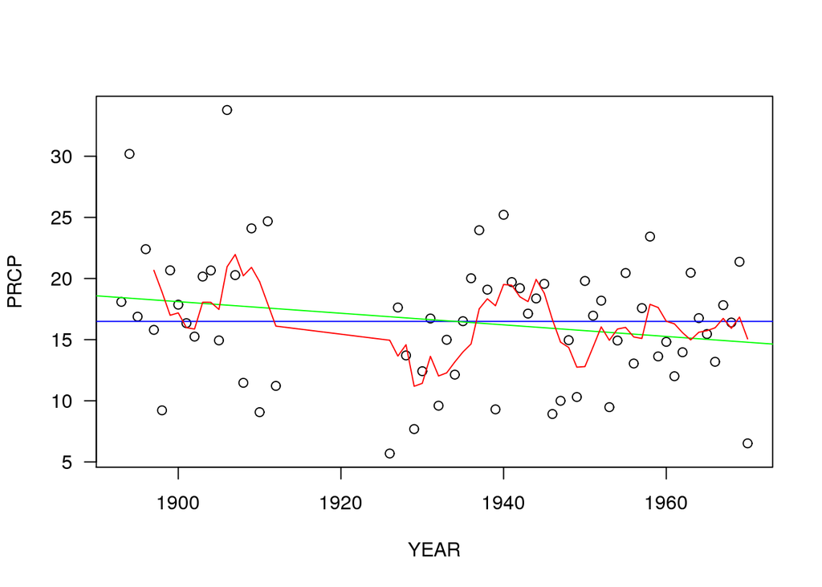

```r
y_lag <- stats::filter(YearlySum$PRCP, k, sides=1)
lines(YearlySum$YEAR, y_lag, col="red")
```

The model suggests that the precipitation is declines at a rate of -0.0474315 cm yr$^{-1}~$, or -0.47 cm decade$^{-1}$.

```r
summary(YearlySum.lm)
```

```
##
## Call:
## lm(formula = PRCP ~ YEAR, data = YearlySum)
##
## Residuals:
##      Min       1Q   Median       3Q      Max
## -11.1850  -3.0701   0.0619   2.8897  15.9564
##
## Coefficients:
##              Estimate Std. Error t value Pr(>|t|)
## (Intercept) 108.22801   53.66935   2.017   0.0480 *
## YEAR         -0.04743    0.02775  -1.709   0.0923 .
## ---
## Signif. codes:  0 '***' 0.001 '**' 0.01 '*' 0.05 '.' 0.1 ' ' 1
##
## Residual standard error: 5.332 on 63 degrees of freedom
## Multiple R-squared:  0.04432,    Adjusted R-squared:  0.02915
## F-statistic: 2.922 on 1 and 63 DF,  p-value: 0.09231
```

Other attempts that didn’t work!

```r
YearlySum2 = subset(YearlySum, select=c(PRCP))
YearlyMean = mean(YearlySum2$PRCP)

#filter(YearlySum2)



#Doesn't work...
# ma <- function(x,n=5){filter(x,rep(1/n,n), sides=2)}
# ma(YearlySum$PRCP)


yearlyts =ts(YearlySum2)
str(yearlyts)
```

```
##  Time-Series [1:65, 1] from 1 to 65: 18.1 30.2 16.9 22.4 15.8 ...
##  - attr(*, "dimnames")=List of 2
##   ..$ : NULL
##   ..$ : chr "PRCP"
```

yearlyts.lag = lag(yearlyts, 5)[6:112,]; head(yearlyts.lag)

plot(yearlyts, lty = 1, col = 3)

lines(yearlyts.lag)

lines(Departure ~ YEAR, data=YearlySum, col=“red”)